# Project Outline 📑

- 1. High Level Data Exploration
- 2. Exploratory Data Analysis📊
  - 2.1 Univariate Analysis
  - 2.2 Bivariate Analysis
  - 2.3 Multivariate Analysis
- 3. Data Preprocessing and Cleaning
- 4. Model Implementation

# Bank Customer Churn Prediction Project

## Introduction

This project focuses on predicting bank customer churn—whether a customer will leave or stay—using various personal and behavioral attributes. Customer retention is vital for banks, as keeping current customers is significantly more cost-effective than gaining new ones. By identifying the key factors driving churn, banks can develop targeted loyalty and retention strategies to minimize customer turnover. We will build a predictive model using a dataset from [Kaggle](https://www.kaggle.com/datasets/radheshyamkollipara/bank-customer-churn/data) containing customer information and behavioral data.

## Dataset Description

The dataset contains 18 columns, each representing a feature of a bank customer. These features include demographic details, financial information, customer engagement, and feedback metrics. Below is a detailed description of the columns, grouped by their relevance for better understanding:

| **Category** | **Column Name** | **Description** |
| --- | --- | --- |
| **Identifiers** | RowNumber | A sequential number for each record. |
|  | CustomerId | A unique identifier for each customer. |
|  | Surname | The customer's last name. |
| **Demographic Information** | Geography | The country/region of the customer (e.g., France, Germany, Spain). Location may influence churn behavior. |
|  | Gender | The customer’s gender (Male/Female). May show patterns in churn behavior. |
|  | Age | The customer’s age. Older customers are generally more loyal and less likely to churn. |
| **Financial Information** | CreditScore | The customer’s credit score (300–850). Higher scores indicate lower likelihood of churn. |
|  | Balance | The amount in the customer’s account. Higher balances often correlate with lower churn rates. |
|  | EstimatedSalary | The estimated salary of the customer. Higher salaries may indicate financial stability and lower churn. |
| **Customer Engagement** | Tenure | The number of years the customer has been with the bank. Longer tenure suggests higher loyalty. |
|  | NumOfProducts | The number of bank products (e.g., accounts, loans) the customer uses. More products may reduce churn likelihood. |
|  | HasCrCard | Whether the customer has a credit card (0 = No, 1 = Yes). Credit card holders are less likely to churn. |
|  | IsActiveMember | Whether the customer is an active user (0 = No, 1 = Yes). Active customers are less likely to leave. |
|  | Card Type | The type of credit card (e.g., Visa, MasterCard). May reflect customer preferences or financial status. |
|  | Points Earned | Points earned from credit card usage. Higher points may indicate satisfaction and lower churn risk. |
| **Customer Feedback** | Complain | Whether the customer has filed a complaint (0 = No, 1 = Yes). Complaints are a strong indicator of potential churn. |
|  | Satisfaction Score | The score (likely 1–5) given by the customer for complaint resolution. Impacts churn likelihood. |
| **Target Variable** | Exited | Whether the customer left the bank (0 = Stayed, 1 = Left). This is the target variable for prediction. |

## Project Objective

This project's core purpose is to develop an accurate machine learning model to predict customer churn (leaving the bank). By isolating the main churn drivers, such as high complaints, bank balance, or customer age, the bank can implement proactive retention measures like better complaint handling or personalized service offerings.

## Project Workflow

This project employs a standard data science pipeline to develop a robust predictive model for customer churn (the 'Exited' variable).

1. **Data Exploration (EDA)**: Systematically analyze the dataset to understand the underlying structure, relationships, and feature characteristics.
   - **Univariate Analysis**: Profile individual features (e.g., age distribution, balance characteristics).
   - **Bivariate Analysis**: Examine correlations between feature pairs and the target variable (e.g., age vs. churn rate).
   - **Multivariate Analysis**: Investigate complex feature interactions to reveal multi-factor patterns.
2. **Data Cleaning and Preprocessing**: Handle missing values, encode categorical variables (e.g., Geography, Card Type), remove irrelevant columns (e.g., RowNumber, CustomerId, Surname), Apply synthetic data sampling techniques as necessary to balance the dataset, and prepare the data for modeling.
3. **Predictive Modeling**: Construct and train a diverse set of classification algorithms to predict customer exit. Models: Logistic Regression, Support Vector Classifier (SVC), Random Forest, AdaBoost, and XGBoost.
4. **Evaluation and Recommendations**: Rigorously evaluate model efficacy using key classification metrics and identify the most important features driving churn to deliver actionable, data-backed recommendations for the bank's retention strategy.

## Load required libraries, functions, presets, and data

```
Data source import complete.
```

## Custom Functions

```
Graphing Functions:  plot_distributions, plot_categorical_features, three_way_cat_cont_interactions, corr_plot_func
```

```
Three-way Association Regression Functions:  log_lin_3_way_cat_association, pairwise_loglin_homogenous_posthoc, pairwise_loglin_simple_heterogenous_posthoc, stratified_categorical_logistic_regression
```

```
Three-way Association Non-Parametric Functions:  alighed_rank_transform_anova, art_contrast_posthoc_unified
```

```
Alternative Three-way Association Regression Functions:  stratified_logistic_regression_with_posthoc
```

```
ANOVA Functions:  cust_one_way_ANOVA, cust_two_way_ANOVA
```

```
Non-Parametric ANOVA Functions:  kruskal_wallis_with_dunn
```

# 1. High Level Data Exploration

## Displaying a Random Sample of the Data

|  | RowNumber | CustomerId | Surname | CreditScore | Geography | Gender | Age | Tenure | Balance | NumOfProducts | HasCrCard | IsActiveMember | EstimatedSalary | Exited | Complain | Satisfaction Score | Card Type | Point Earned |
| --- | --- | --- | --- | --- | --- | --- | --- | --- | --- | --- | --- | --- | --- | --- | --- | --- | --- | --- |
| 8086 | 8087 | 15774847 | Knight | 593 | France | Male | 50 | 6 | 171740.69 | 1 | 0 | 0 | 20893.61 | 0 | 0 | 4 | SILVER | 602 |
| 5633 | 5634 | 15715877 | Lo | 821 | France | Male | 28 | 2 | 0.00 | 2 | 1 | 0 | 46072.52 | 0 | 0 | 2 | DIAMOND | 544 |
| 403 | 404 | 15732674 | Fennell | 443 | Spain | Male | 36 | 6 | 70438.01 | 2 | 0 | 1 | 56937.43 | 0 | 0 | 4 | GOLD | 858 |
| 8906 | 8907 | 15797065 | Goloubev | 613 | Spain | Female | 32 | 0 | 0.00 | 2 | 0 | 1 | 126675.62 | 0 | 0 | 5 | DIAMOND | 963 |
| 2060 | 2061 | 15747980 | Cattaneo | 737 | Spain | Male | 38 | 6 | 146282.79 | 2 | 1 | 0 | 198516.20 | 0 | 0 | 5 | PLATINUM | 703 |

## Data Overview

Upon initial inspection, the columns RowNumber, CustomerID, and Surname add no value to predicting Exited in our case and will therefore be removed. The majority of our features consist of integer and float data. Variables such as "Complain", "Exited", etc should be labeled as categorical, we will update this before analysis.

```
<class 'pandas.core.frame.DataFrame'>
RangeIndex: 10000 entries, 0 to 9999
Data columns (total 18 columns):
 #   Column              Non-Null Count  Dtype
---  ------              --------------  -----
 0   RowNumber           10000 non-null  int64
 1   CustomerId          10000 non-null  int64
 2   Surname             10000 non-null  object
 3   CreditScore         10000 non-null  int64
 4   Geography           10000 non-null  object
 5   Gender              10000 non-null  object
 6   Age                 10000 non-null  int64
 7   Tenure              10000 non-null  int64
 8   Balance             10000 non-null  float64
 9   NumOfProducts       10000 non-null  int64
 10  HasCrCard           10000 non-null  int64
 11  IsActiveMember      10000 non-null  int64
 12  EstimatedSalary     10000 non-null  float64
 13  Exited              10000 non-null  int64
 14  Complain            10000 non-null  int64
 15  Satisfaction Score  10000 non-null  int64
 16  Card Type           10000 non-null  object
 17  Point Earned        10000 non-null  int64
dtypes: float64(2), int64(12), object(4)
memory usage: 1.4+ MB
```

> Fortunatly there are no missing datapoints or duplicates!

```
 Table of missing data per column:
```

```
RowNumber             0
CustomerId            0
Surname               0
CreditScore           0
Geography             0
Gender                0
Age                   0
Tenure                0
Balance               0
NumOfProducts         0
HasCrCard             0
IsActiveMember        0
EstimatedSalary       0
Exited                0
Complain              0
Satisfaction Score    0
Card Type             0
Point Earned          0
dtype: int64
```

```
------------------------------

Count of duplicate Rows:
```

```
0
```

# 2. Exploratory Data Analysis

We'll start with **Exploratory Data Analysis (EDA)** to get a clear picture of the dataset, looking for patterns and relationships that influence customer churn. This analysis is broken down into three focused stages:

1. **Univariate Analysis**: Examining each feature's individual characteristics (like age or credit score) using statistics and visualizations to spot outliers or skewness.
2. **Bivariate Analysis**: Investigating how pairs of features relate to the target variable, Exited (churn), to identify strong predictors using plots and correlation methods.
3. **Multivariate Analysis**: Exploring the complex interactions among multiple features to uncover deeper patterns that simpler analyses miss.

The insights gained from this structured EDA will highlight any necessary corrections, like handling imbalanced data or outliers, which we'll address in the Data Cleaning and Preprocessing stage before we build our predictive models.

## 2.1 Univariate Analysis

> To begin, we will split the features between numerical and categorical as treatment differs between datatypes in univeriate analysis.

```
 Numerical Columns:
  ['CreditScore', 'Age', 'Tenure', 'Balance', 'EstimatedSalary', 'Point Earned']

 Categorical Columns:
  ['Geography', 'Gender', 'NumOfProducts', 'HasCrCard', 'IsActiveMember', 'Exited', 'Complain', 'Satisfaction Score', 'Card Type']


Updated Feature Types:

<class 'pandas.core.frame.DataFrame'>
RangeIndex: 10000 entries, 0 to 9999
Data columns (total 15 columns):
 #   Column              Non-Null Count  Dtype
---  ------              --------------  -----
 0   CreditScore         10000 non-null  int64
 1   Geography           10000 non-null  category
 2   Gender              10000 non-null  category
 3   Age                 10000 non-null  int64
 4   Tenure              10000 non-null  int64
 5   Balance             10000 non-null  float64
 6   NumOfProducts       10000 non-null  category
 7   HasCrCard           10000 non-null  category
 8   IsActiveMember      10000 non-null  category
 9   EstimatedSalary     10000 non-null  float64
 10  Exited              10000 non-null  category
 11  Complain            10000 non-null  category
 12  Satisfaction Score  10000 non-null  category
 13  Card Type           10000 non-null  category
 14  Point Earned        10000 non-null  int64
dtypes: category(9), float64(2), int64(4)
memory usage: 558.1 KB
```

## Numerical Features Analysis

```
 Summary Statistis:
```

|  | CreditScore | Age | Tenure | Balance | EstimatedSalary | Point Earned |
| --- | --- | --- | --- | --- | --- | --- |
| count | 10000.00 | 10000.00 | 10000.00 | 10000.00 | 10000.00 | 10000.00 |
| mean | 650.53 | 38.92 | 5.01 | 76485.89 | 100090.24 | 606.52 |
| std | 96.65 | 10.49 | 2.89 | 62397.41 | 57510.49 | 225.92 |
| min | 350.00 | 18.00 | 0.00 | 0.00 | 11.58 | 119.00 |
| 25% | 584.00 | 32.00 | 3.00 | 0.00 | 51002.11 | 410.00 |
| 50% | 652.00 | 37.00 | 5.00 | 97198.54 | 100193.91 | 605.00 |
| 75% | 718.00 | 44.00 | 7.00 | 127644.24 | 149388.25 | 801.00 |
| max | 850.00 | 92.00 | 10.00 | 250898.09 | 199992.48 | 1000.00 |

### Let's visualize this information!

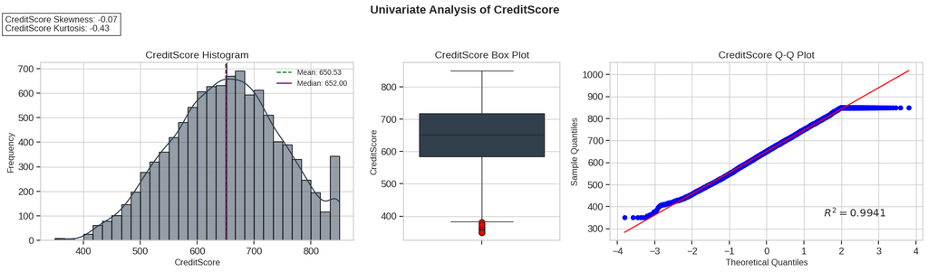

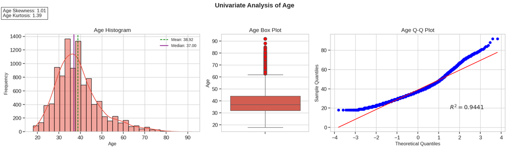

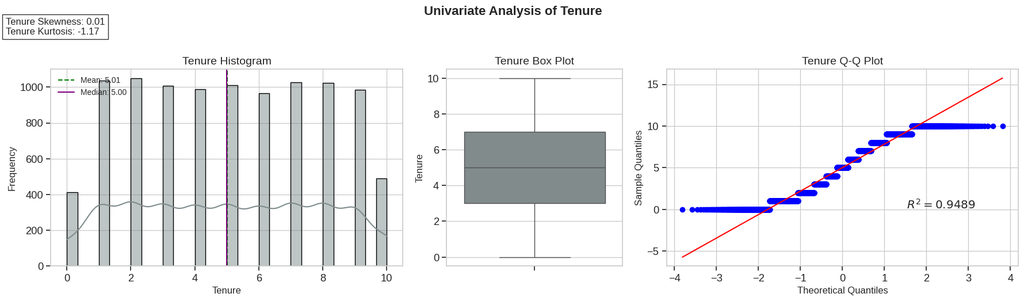

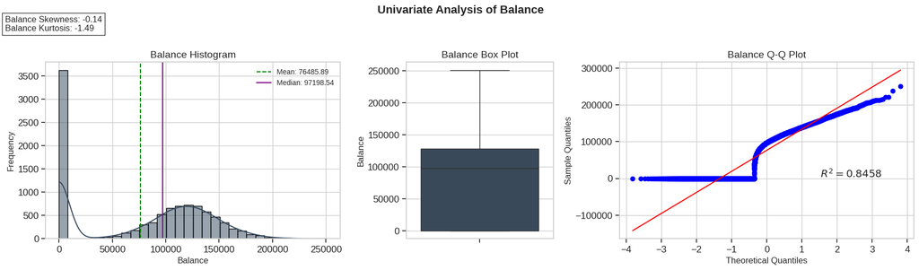

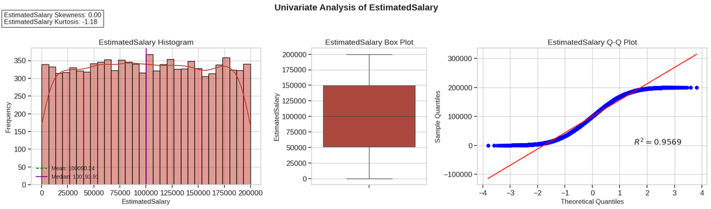

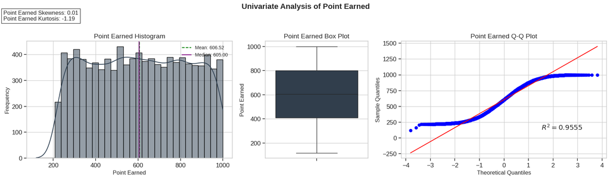

### Univariate Analysis: Numerical Features

This analysis explores the distributions of the key numerical features—CreditScore, Age, Tenure, Balance, EstimatedSalary, and Point Earned—in the Bank Customer Churn dataset. The goal is to interpret their univariate distributions, identify non-normality or unusual patterns, and propose specific preprocessing strategies for effective model building. We will leverage provided histograms, box plots, and summary statistics, including Q-Q plot $R^2$ values, as evidence.

### Balance Revisited

When only considering the non-zero balances, the distribution is highly symmetrical (Skewness: 0.03) and exhibits an excellent fit to a normal distribution. The high Q-Q plot $R^2$ of 0.9993 strongly confirms its near-perfect normality.

- **Insight:** This finding is crucial: the zero-inflated nature was the cause of non-normality in the original variable. By separating the two populations (zero balance vs. non-zero balance), the continuous part of the feature (Balance >0) is now exceptionally well-behaved (see below plots).
- **Preprocessing Strategy and Rationale:**
  1. **Feature Engineering:** A new binary feature, "HasZeroBalance", has been created to capture the effect of an inactive or savings-only account. This addresses the structural issue of zero-inflation.
  2. **Multicollinearity Management:** If both the original Balance (including zero balance) and the new "HasZeroBalance" feature are kept in the model, would capture two distinct effects:
     - The binary effect: Does having any balance matter?
     - The continuous effect: Does the magnitude of the balance matter? This introduces multicollinearity, which will be managed in the modeling phase using regularization techniques (e.g., Lasso or Ridge regression) rather than discarding valuable information. However, there is still review to be done whether both variables will make it to the final model or not.
  3. **Action: Scaling (StandardScaler)** of Balance will be suitable. Since this distribution is already virtually normal when not accounting for zeros and lacks significant outliers all together, scaling is preferred over a logarithmic transformation. A log transform would unduly compress the high balances, which, being within a highly symmetrical distribution, are already statistically realistic and informative.

```
 Case when zero balances have been removed from Balance:
```

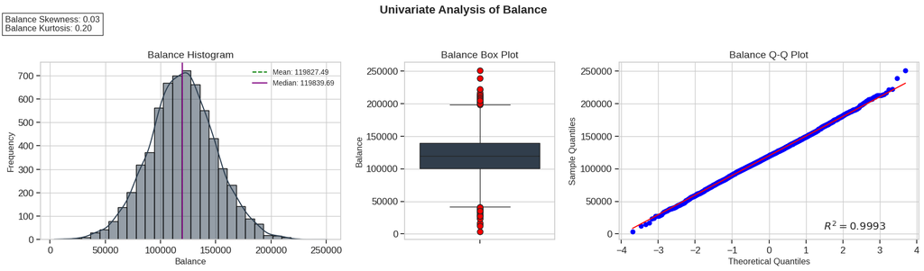

```
Case when original Balance is log1p transformed:
```

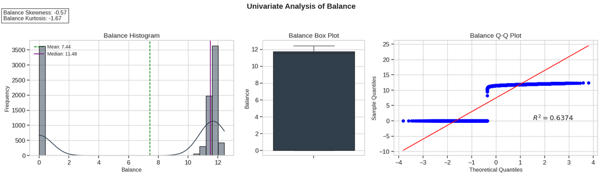

## Categorical Features Analysis

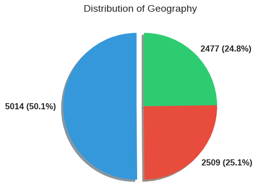

```
+---------+---------+--------------------------+
| Value   |   Count |   Relative Frequency (%) |
|---------+---------+--------------------------|
| France  |    5014 |                     50.1 |
| Germany |    2509 |                     25.1 |
| Spain   |    2477 |                     24.8 |
+---------+---------+--------------------------+
```

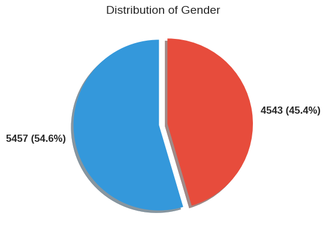

```
+---------+---------+--------------------------+
| Value   |   Count |   Relative Frequency (%) |
|---------+---------+--------------------------|
| Male    |    5457 |                     54.6 |
| Female  |    4543 |                     45.4 |
+---------+---------+--------------------------+
```

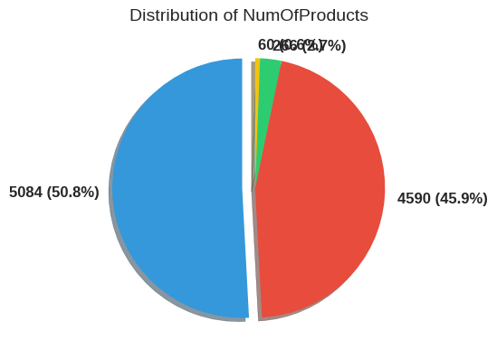

```
+---------+---------+--------------------------+
|   Value |   Count |   Relative Frequency (%) |
|---------+---------+--------------------------|
|       1 |    5084 |                     50.8 |
|       2 |    4590 |                     45.9 |
|       3 |     266 |                      2.7 |
|       4 |      60 |                      0.6 |
+---------+---------+--------------------------+
```

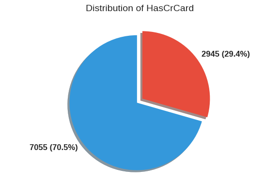

```
+---------+---------+--------------------------+
|   Value |   Count |   Relative Frequency (%) |
|---------+---------+--------------------------|
|       1 |    7055 |                     70.6 |
|       0 |    2945 |                     29.4 |
+---------+---------+--------------------------+
```

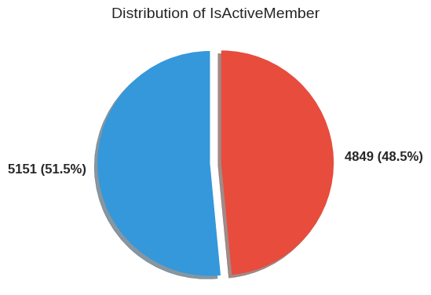

```
+---------+---------+--------------------------+
|   Value |   Count |   Relative Frequency (%) |
|---------+---------+--------------------------|
|       1 |    5151 |                     51.5 |
|       0 |    4849 |                     48.5 |
+---------+---------+--------------------------+
```

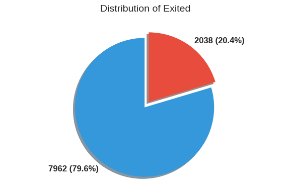

```
+---------+---------+--------------------------+
|   Value |   Count |   Relative Frequency (%) |
|---------+---------+--------------------------|
|       0 |    7962 |                     79.6 |
|       1 |    2038 |                     20.4 |
+---------+---------+--------------------------+
```

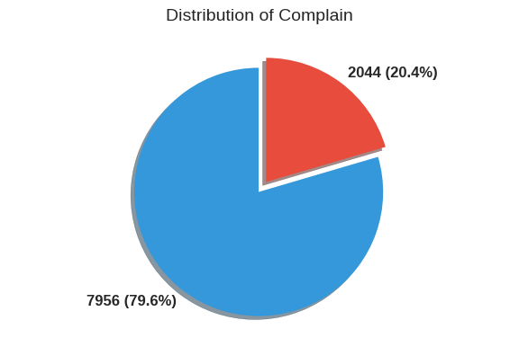

```
+---------+---------+--------------------------+
|   Value |   Count |   Relative Frequency (%) |
|---------+---------+--------------------------|
|       0 |    7956 |                     79.6 |
|       1 |    2044 |                     20.4 |
+---------+---------+--------------------------+
```

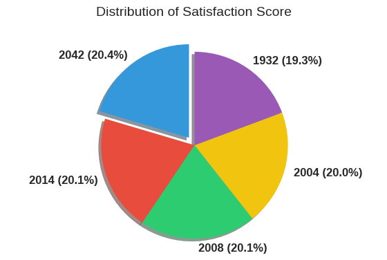

```
+---------+---------+--------------------------+
|   Value |   Count |   Relative Frequency (%) |
|---------+---------+--------------------------|
|       3 |    2042 |                     20.4 |
|       2 |    2014 |                     20.1 |
|       4 |    2008 |                     20.1 |
|       5 |    2004 |                     20   |
|       1 |    1932 |                     19.3 |
+---------+---------+--------------------------+
```

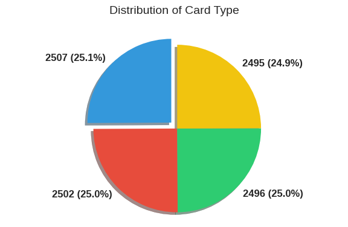

```
+----------+---------+--------------------------+
| Value    |   Count |   Relative Frequency (%) |
|----------+---------+--------------------------|
| DIAMOND  |    2507 |                     25.1 |
| GOLD     |    2502 |                     25   |
| SILVER   |    2496 |                     25   |
| PLATINUM |    2495 |                     25   |
+----------+---------+--------------------------+
```

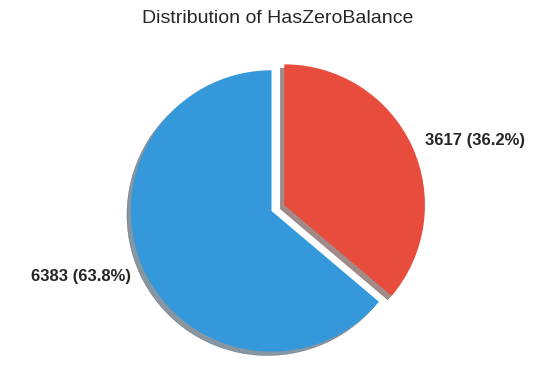

```
+---------+---------+--------------------------+
|   Value |   Count |   Relative Frequency (%) |
|---------+---------+--------------------------|
|       0 |    6383 |                     63.8 |
|       1 |    3617 |                     36.2 |
+---------+---------+--------------------------+
```

### Univariate Analysis Insights: Categorical Features

This section presents the univariate analysis of the Bank Customer Churn dataset's categorical features, revealing critical insights into customer demographics and engagement. Understanding these distributions is vital for shaping our modeling approach and preprocessing strategy.

#### Preprocessing Plan

Based on these findings, we will move forward with encoding the following nominal features:

- **Encoding Categorical Variables:** Geography, Gender, and Card Type will be transformed into numerical features using one-hot encoding, as they lack any inherent ordinal relationship.
- **Handling Ordinal Variables:** Satisfaction Score and NumOfProducts inherently contain rank information (ordinality), however they will also be transformed using one-hot encoding to assess the purely predictive nature of each level.
- **Binary Features (Ready to Use):** The variables Exited, Complain, HasCrCard, IsActiveMember, and HasZeroBalance are already encoded as binary (0 or 1). No further preprocessing or encoding is required for these features.

## 2.2 Bivariate Analysis: Linking Features to Churn

Following the univariate insights, the next critical step is the Bivariate Analysis. This phase shifts focus to how individual features interact with our target variable, Exited (Churn). Our primary goal is to move beyond simple distributions and systematically identify the true correlations and dependencies that drive customer attrition. We will use visualization techniques, such as box plots, heatmaps, and contingency tables, alongside calculated correlation coefficients, to uncover the most predictive relationships. The findings here will directly inform our final feature selection and influence subsequent modeling decisions.

## Correlation Analysis

To clearly identify the factors most strongly associated with customer churn, we segmented our correlation analysis into four strategic categories: Demographics, Financials, Engagement, and Feedback. This approach allows us to easily visualize how variables relate to our target outcome, Exiting (Churn), as well as how variables within each group interact.

We used Spearman's Rank Correlation for this analysis because the underlying data distribution for most variables is non-normal. To include our categorical data, all such variables were converted into binary (0 or 1) indicators.

Our initial analysis focuses on the demographics group: Geography, Gender, and Age. Reviewing the correlation results (specifically the row for "Exited_1" [Churn]), we observe the following key insights regarding customer characteristics:

- Age is the strongest demographic driver of churn with a correlation of 0.32. This suggests that older customers are significantly more likely to exit.
- Geography is the second most correlated factor. Customers located in Germany show a higher association with exiting compared to customers in other regions within our dataset.
- Gender also shows a measurable correlation. Specifically, the data indicates a positive correlation with the female segment and a negative correlation with the male segment. This suggests that female customers are disproportionately associated with the decision to churn in our sample.

This early segmentation helps us prioritize which customer profiles (older, female, German-based) require immediate attention and targeted retention strategies.

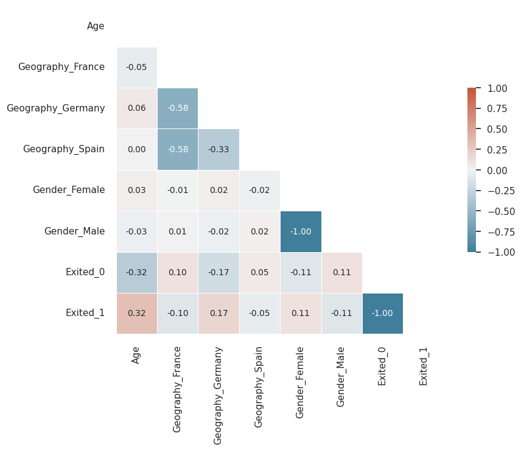

Next, we examined the customer financial data group, which includes Estimated Salary, Account Balance (continuous), Has Zero Balance (binary), and Credit Score.

Looking at the correlation results with the Exited (Churn) outcome, we find that the variables in this group generally show weak correlations with churn.

- The highest, albeit still low, correlations are observed with Account Balance (continuous) and the Has Zero Balance indicator.
- Balance as a continuous variable shows a positive correlation with churn, meaning customers with larger account balances are slightly more associated with exiting.
- The binary variable Has Zero Balance shows a negative correlation. This is logical: since the binary variable is coded '1' for a zero balance, the negative correlation indicates that customers with zero balances are less associated with exiting compared to those who hold money with the bank.

Given the similar, small magnitude of correlation for these two Balance-related variables, they essentially provide **redundant information** regarding the likelihood of churn. Overall, the financial data, outside of Balance itself, is not a primary driver of churn in this model.

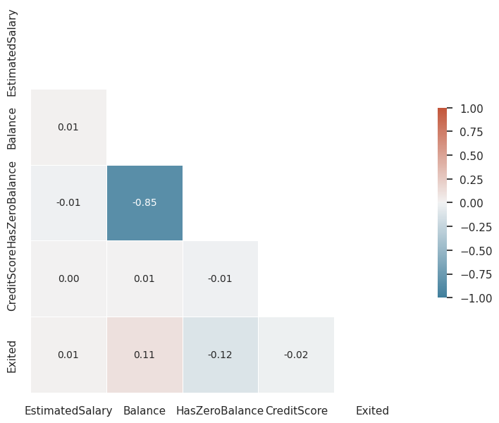

We next analyzed customer engagement data, including Tenure, Points Earned, Number of Products, Credit Card Ownership, Active Member Status, and Card Type.

Looking at the correlation results with Exited (Churn), the key drivers are Number of Products and Active Member Status.

- Number of Products shows the most significant correlation within this group. Intriguingly, customers holding two products are more likely to be retained (less likely to exit) compared to those with one, three, or four products, all of which show a higher association with churn. This finding highlights a specific retention sweet spot at the two-product level and warrants deeper investigation.
- Active Member Status shows the expected negative correlation with churn. This confirms that customers who are flagged as Active Members are less likely to exit compared to those who are inactive.

Other variables like Tenure, Points Earned, and Credit Card Ownership showed negligible correlation with the churn outcome. This suggests that retention efforts should heavily prioritize **increasing active member rates** and understanding the dynamics around **product bundling**.

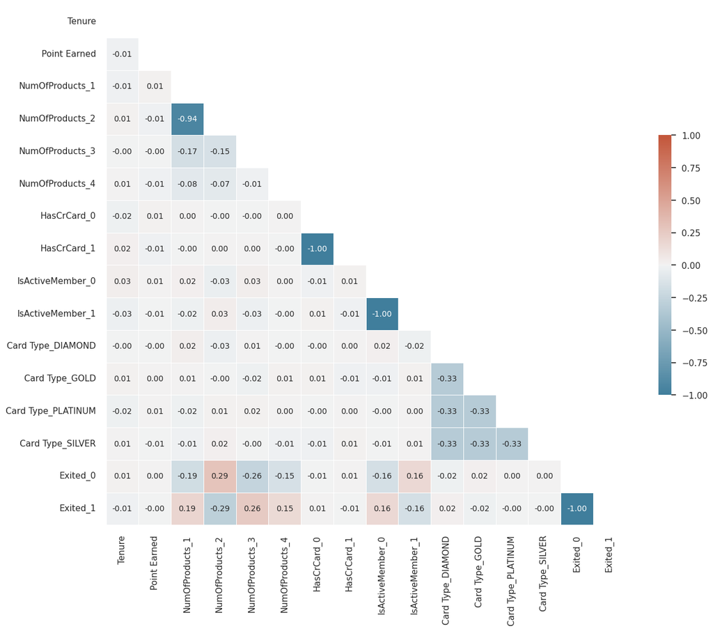

Finally, we examined the customer feedback data, which includes a Complaint indicator (did the customer complain?) and their Satisfaction Score regarding complaint resolution.

Our analysis of the correlation with Exited (Churn) reveals a significant disparity:

- We found no discernible correlation between a customer's Satisfaction Score regarding issue resolution and their decision to exit. This suggests that simply resolving a complaint may not prevent churn if the underlying issue is severe.
- In stark contrast, we observe an extremely strong, almost perfect correlation between customers who complain and those who subsequently exit.

This near-perfect correlation between filing a complaint and churning is an extreme finding that clearly identifies complaints as a **critical and immediate precursor to customer loss**. This warrants immediate and deeper investigation.

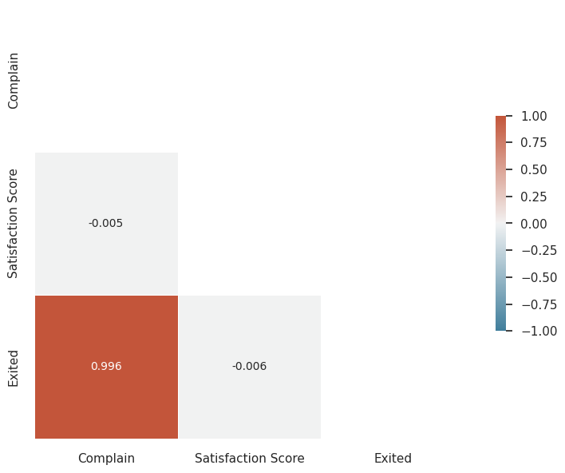

After analyzing correlations within each segment, we ran all inter-group correlations and identified the **top 30 strongest relationships (by absolute value)** across the entire dataset.

The variables that demonstrate the highest and most frequent correlations across different business categories are: Geographical Location, Number of Products, Has Zero Balance, Complaint Indicator, Active Member Status, and Age.

This prioritized list of six variables will be critical. It confirms that the most influential variables regarding customer behavior are not isolated; they frequently interact across the Demographics, Financials, and Engagement categories. We will use these top cross-category correlations to guide the next phase of our analysis, focusing on how these relationships collectively drive the decision to exit.

|  | Var1 | Var2 | correlation |
| --- | --- | --- | --- |
| 0 | Geography_Germany | HasZeroBalance_1 | -0.44 |
| 1 | Geography_Germany | HasZeroBalance_0 | 0.44 |
| 2 | HasZeroBalance_1 | NumOfProducts_2 | 0.39 |
| 3 | HasZeroBalance_0 | NumOfProducts_2 | -0.39 |
| 4 | HasZeroBalance_1 | NumOfProducts_1 | -0.39 |
| 5 | HasZeroBalance_0 | NumOfProducts_1 | 0.39 |
| 6 | Geography_Germany | Balance | 0.37 |
| 7 | Balance | NumOfProducts_2 | -0.34 |
| 8 | Balance | NumOfProducts_1 | 0.33 |
| 9 | Age | Complain_1 | 0.32 |
| 10 | Age | Complain_0 | -0.32 |
| 11 | NumOfProducts_2 | Complain_0 | 0.29 |
| 12 | NumOfProducts_2 | Complain_1 | -0.29 |
| 13 | NumOfProducts_3 | Complain_1 | 0.26 |
| 14 | NumOfProducts_3 | Complain_0 | -0.26 |
| 15 | Geography_France | HasZeroBalance_1 | 0.25 |
| 16 | Geography_France | HasZeroBalance_0 | -0.25 |
| 17 | Geography_France | Balance | -0.21 |
| 18 | NumOfProducts_1 | Complain_0 | -0.18 |
| 19 | NumOfProducts_1 | Complain_1 | 0.18 |
| 20 | Geography_Germany | Complain_1 | 0.18 |
| 21 | Geography_Germany | Complain_0 | -0.18 |
| 22 | IsActiveMember_1 | Complain_0 | 0.15 |
| 23 | IsActiveMember_0 | Complain_1 | 0.15 |
| 24 | IsActiveMember_1 | Complain_1 | -0.15 |
| 25 | IsActiveMember_0 | Complain_0 | -0.15 |
| 26 | NumOfProducts_4 | Complain_0 | -0.15 |
| 27 | NumOfProducts_4 | Complain_1 | 0.15 |
| 28 | Geography_Spain | HasZeroBalance_1 | 0.15 |
| 29 | Geography_Spain | HasZeroBalance_0 | -0.15 |

## Effect of complaints on curn

The Complain variable has demonstrated a near-perfect predictive relationship with churn. Almost every customer who exited the bank ($\text{Churn}=1$) first filed a complaint ($\text{Complain}=1$). Conversely, scarcely any non-complaining customers exited. This makes Complain an exceptionally powerful predictor.  
While highly predictive, this near-perfect relationship introduces a technical problem known as quasi-complete separation . This statistical instability causes the estimated coefficients in models like logistic regression (and their associated standard errors) to become unstable, inflated, or mathematically unreliable.  
Our primary objective is to predict churn among the existing customer base. Given this goal, the Complain variable is an indispensable, early indicator of risk. We will therefore retain this variable, treating customers who complain as a high-threat cohort on the verge of attrition.

- Note on Alternative Goals: If the modeling goal were to predict the churn propensity of a **new** customer (before any service interaction), we would be forced to remove Complain, as its value would be unknown at the time of prediction. Since we are modeling current customer risk, retention is justified.

To manage the statistical instability caused by the separation, we will apply regularization techniques (such as L1 or L2 penalties) to stabilize the model's coefficient estimates. Our current analytical focus shifts to the small, crucial group of 10 customers who complained but ultimately chose to stay and the 4 customers who churned but did not have a complaint. Identifying the unique characteristics and mitigating factors that prevented their churn is now our top priority, as these insights are invaluable for developing effective retention strategies.

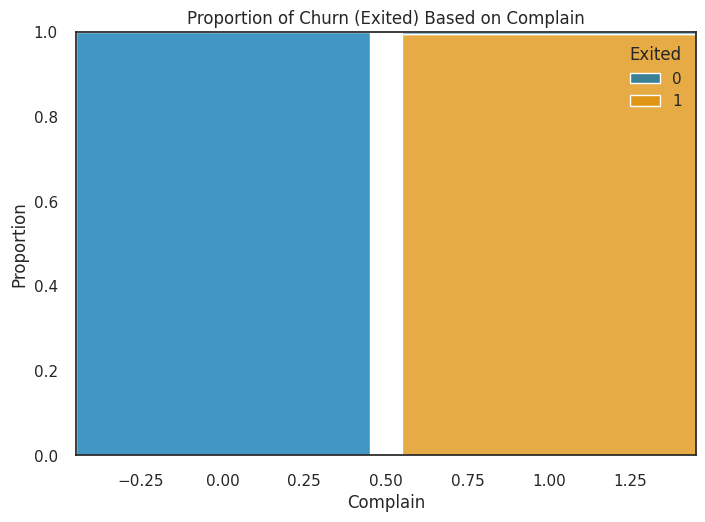

```
Count of customer's who complained but didn't churn:  10


Count of customer's who churned but didn't complain:  4
```

## Product Engagement Effect on Churn

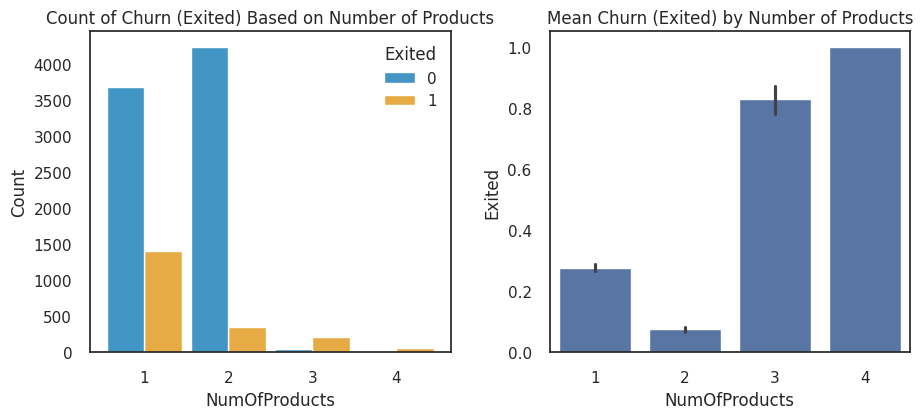

```
Chi-Square Statistic: 1501.505, p-value: 0.000
```

## Geographical Effects on Churn

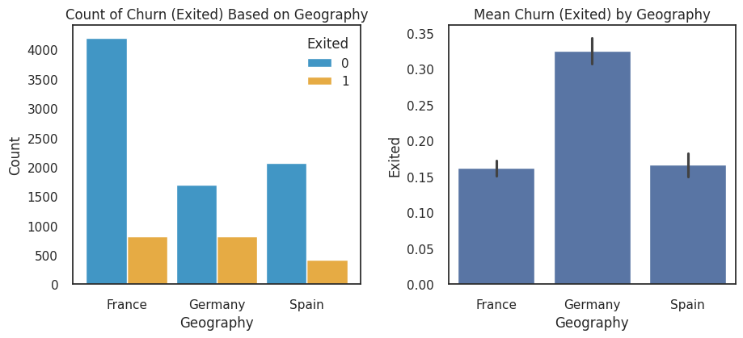

```
Chi-Square Statistic: 300.626, p-value: 0.000
```

## Gender Effects on Churn

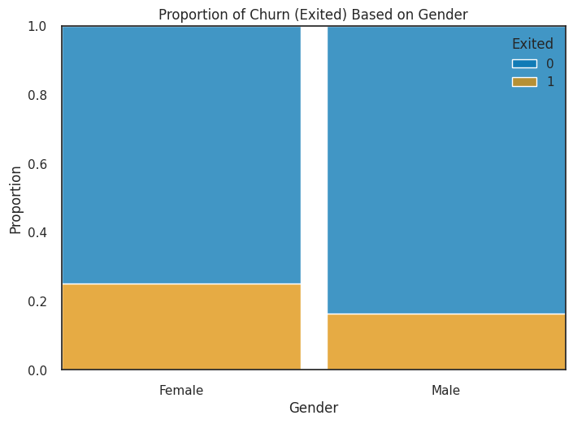

```
Chi-Square Statistic: 112.397, p-value: 0.000
```

## Active Members Effects on Churn

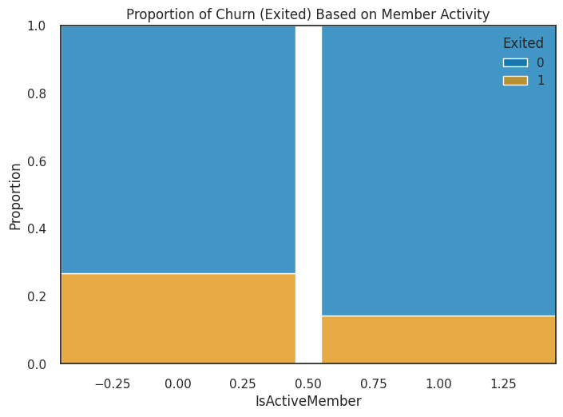

```
Chi-Square Statistic: 243.695, p-value: 0.000
```

## Zero Balance Members Effects on Churn

A statistically significant disparity exists in churn based on account balance. Customers with a positive balance churn at a much higher rate (around 24%) than those with a zero balance (about 14%). This result is counter-intuitive, as it suggests that holding a balance is associated with a greater likelihood of exiting, despite the prior finding that inactive customers (who often have zero balances) are typically higher risk. Unfortunately we do not have the right data to dive deeper into this question.

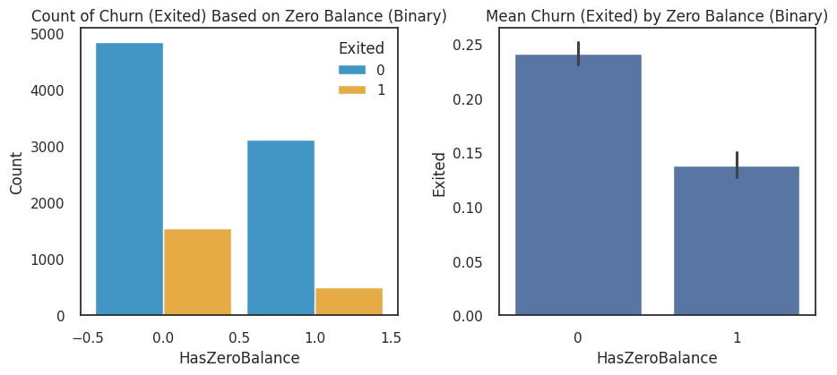

```
Chi-Square Statistic: 149.484, p-value: 0.000
```

## Effects of Age on Churn

The analysis of Age reveals a substantial difference in distributions between customers who exited (1) and those who did not (0), establishing age as a highly significant predictor of churn.  
Specifically, the majority of active (non-exited) customers are concentrated in a younger demographic, with their core age range lying between 30 and 41 years old. In sharp contrast, customers who have churned are notably older, with their core age range spanning 38 to 51 years. This upward shift in age for the Exited group strongly suggests that older customers are at a significantly higher risk of attrition.

> The disparity in the median ages between the two cohorts is also statistically significant, further confirming that this relationship is not due to random chance and solidifying Age as a critical factor in predicting customer departure.

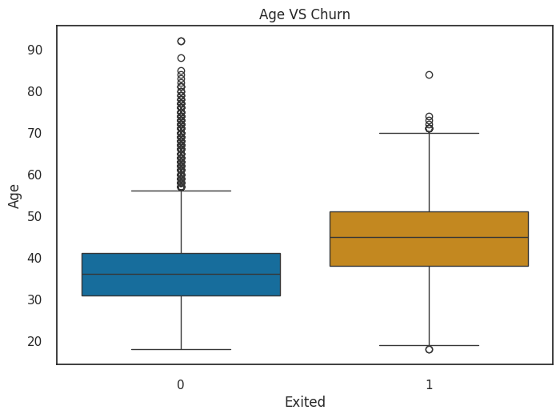

```
Mann-Whitney U Statistic: 4347741.000, p-value: 0.000
```

## Effects of Overall Balance on Churn

An analysis of the balance distributions for customers with a positive balance (for example, by looking at histograms separated by churn status) reveals a key insight: the density distributions for customers who churned and those who did not are remarkably similar. This finding suggests that holding a very high positive balance, compared to a moderate positive balance, does not inherently change a customer's likelihood of leaving the service.

We must be careful when testing the statistical significance of the raw Balance variable (the continuous variable) across its entire range. The distribution of non-churned customers has a significantly higher proportion of zero-balance accounts than the distribution of churned customers. If we test for significance using the entire balance range (including zeros), we will get a statistically significant result. However, this significance is misleading; it's entirely driven by the mean rank difference between zero-balance and positive-balance accounts, not by the variation within the positive balances. To correctly isolate the effect of the continuous balance, we must test for significance only on the subset of customers with a positive balance. When we do this, the positive balance is not a statistically significant predictor of churn. The observed statistical difference when using the full variable is wholly attributable to the overwhelming disparity in the proportion of non-exited customers who maintain a zero balance.

**Recommendation:**  
Because the predictive power is concentrated solely at the distinction between a zero balance and a positive balance, the continuous raw Balance variable is not a useful predictor on its own. The binary feature HasZeroBalance (a value of 1 for zero balance, 0 for positive balance) captures all the necessary information more effectively and parsimoniously. We should rely on the binary HasZeroBalance feature and potentially exclude the raw continuous Balance variable from the final predictive model. This simplifies the model without sacrificing predictive accuracy.

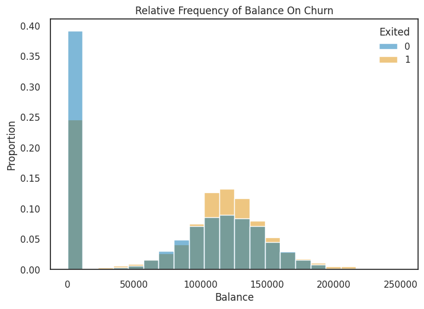

```
Mann-Whitney U Statistic including zero balance: 6852646.500, p-value: 0.000

Mann-Whitney U Statistic on non-zero balance: 3650896.500, p-value: 0.234
```

## Linking Features to Churn Summary

Our initial screening, based on separation by churn status, has identified a robust set of statistically significant predictors of customer attrition. These key drivers include the demographic variables Age and Gender, the behavioral indicators Number of Products, Activeness Status, and whether a Complaint was filed, along with the Geographical location.  
Crucially, our feature engineering effort established that the HasZeroBalance binary variable is analytically superior to the raw, continuous Balance variable. The binary feature will be retained due to its clarity and greater predictive efficacy.

Path Forward: Multivariate Analysis  
The next phase of this study will transition to multivariate analysis. We will focus on exploring the complex relationships among these identified predictor variables. Specifically, we will systematically investigate potential interaction effects, test for mediation (where one variable's effect is explained by a second), and identify any confounding variables that may distort the true relationships between our key predictors and customer churn. This step is essential for building a final predictive model that is both accurate and rigorously interpreted.

## 2.3 Multivariate Analysis

## Product Engagement Effects on Zero Balance and Churn

The analysis confirms a statistically significant interaction effect involving the zero balance status. The effect of a Zero Balance on churn is not uniform; it changes significantly depending on the number of products a customer holds.  
**Recomendation:** We must include the explicit interaction term ($\text{HasZeroBalance} \times \text{Number of Products}$) in the model to accurately capture how these two factors combine to influence churn.

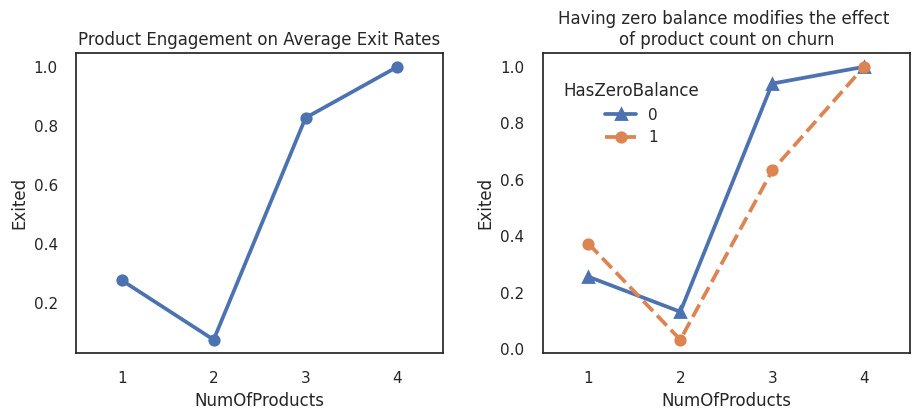

```
CMH equivalent test (Conditional Independence) Statistic: 8.0775, p-value: 0.004

Breslow-Day equivalent test (Homogeneity) Statistic: 240.5787, p-value: 0.000
```

|  | Stratum | comparison | p_value_raw | corrected_p_value | significant |
| --- | --- | --- | --- | --- | --- |
| 0 | 1 | 1 vs 0 | 0.00 | 0.00 | True |
| 1 | 3 | 1 vs 0 | 0.00 | 0.00 | True |
| 2 | 2 | 1 vs 0 | 0.00 | 0.00 | True |
| 3 | 4 | 1 vs 0 (Insufficient Data) | 1.00 | 1.00 | False |